# Building a Model for Human Activity Recognition

Kuhsibiris

February 2, 2017

## Introduction

The set consists of 19622 observation with 160 variables, from these we would like to predict the classe. The labels for this variable are

- A. Doing the exercise correctly
- B. Throwing elbows to the front
- C. Lifting the dumbbell only halfway
- D. Lowering the dumbbell only halfway
- E. Throwing the hips to the front

## Preprossesing

The first step taken is to remove those features that have very little predictibility and thus very little predictive power, in this step we take out all numeric variables that have one or two values, those are:

```
##  [1] "new_window"             "kurtosis_yaw_belt"
##  [3] "skewness_yaw_belt"      "amplitude_yaw_belt"
##  [5] "kurtosis_yaw_dumbbell"  "skewness_yaw_dumbbell"
##  [7] "amplitude_yaw_dumbbell" "kurtosis_yaw_forearm"
##  [9] "skewness_yaw_forearm"   "amplitude_yaw_forearm"
```

In addition we remove the identifier variable as that variable should have no predictive power, the time and the individual as this may induce bias into the model.

This data set has 1.749.623 missing values, as most methods do not perform well when these are present, the solution we take to this problen is imputing the data using the k-nearest neighbors imputation.

```r
trainingpre=preProcess(training,c("center","scale","knnImpute"))
```

Doing an analylis to remove collinear variables we find we must remove the following variables.

```r
unlist(milista2)
```

```
##   [1]   1   2   3   4   5   6   7   8   9  10  10  11  12  13  14  15  16
##  [18]  17  18  19  20  21  22  23  24  25  26  27  28  29  30  31  32  33
##  [35]  34  35  36  37  38  39  40  41  42  43  44  45  46  47  48  49  50
##  [52]  51  52  53  54  55  56  57  58  59  60  61  62  63  64  64  65  66
##  [69]  67  68  69  70  71  72  73  74  75  76  77  78  79  80  81  82  83
##  [86]  84  85  86  87  88  89  90  91  92  92  93  94  95  96  97  98  99
## [103] 100 101 102 103 104 105 106 107 108 109
```

```r
colnames(training2[colnames(training2)%in% colsnum])[c(10,66,95)]
```

```
## [1] "min_roll_belt"    "min_yaw_dumbbell" "min_yaw_forearm"
```

```r
to_remove2<-colnames(training2[colnames(training2)%in% colsnum])[c(10,66,95)]
training2<-training2 %>% dplyr::select(-one_of(to_remove2))
```

This implies that the columns mentioned should be removed..

## Cross validaton

to cross validate we will use k-fold validation using the built-in method in the caret package

```r
train_control<-trainControl(method = "cv",number = 10)
```

## Model

The model was trained using linear discriminant analysis

```r
modelo1<-train(data=training2,method="lda",classe~.-1,trControl=train_control)
modelo1
```

```
## Linear Discriminant Analysis
##
## 19622 samples
##   141 predictors
##     5 classes: 'A', 'B', 'C', 'D', 'E'
##
## No pre-processing
## Resampling: Cross-Validated (10 fold)
## Summary of sample sizes: 17660, 17659, 17660, 17660, 17659, 17662, ...
## Resampling results:
##
##   Accuracy   Kappa
##   0.7926831  0.7379414
##
##
```

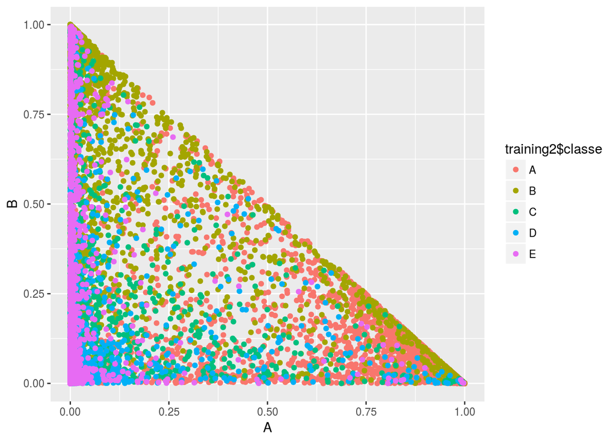

```r
mau<-predict(modelo1$finalModel,modelo1$trainingData[,modelo1$finalModel$xNames])
ggplot(as.data.frame(mau$posterior),aes(x=A,y=B))+geom_point(aes(color=training2$classe))
```

## Acknowledgment

We would like to thank the authors of:

Velloso, E.; Bulling, A.; Gellersen, H.; Ugulino, W.; Fuks, H. Qualitative Activity Recognition of Weight Lifting Exercises. Proceedings of 4th International Conference in Cooperation with SIGCHI (Augmented Human ’13) . Stuttgart, Germany: ACM SIGCHI, 2013.

Read more: http://groupware.les.inf.puc-rio.br/har#ixzz4Xa3rLynU

For letting us use this data set.